# Risk Factor Analysis

## Outcome Variable

**Outcome Variable:** pers_wasted624

## Predictor Variables

**Intervention Variable:** ever_sunderweight06

**Adjustment Set:**

- sex
- arm
- enstunt
- month
- brthmon
- vagbrth
- single
- W_gagebrth
- W_birthwt
- W_birthlen
- W_mage
- W_mhtcm
- W_meducyrs
- W_feducyrs
- W_parity
- delta_month
- delta_brthmon
- delta_vagbrth
- delta_single
- delta_W_gagebrth
- delta_W_birthwt
- delta_W_birthlen
- delta_W_mage
- delta_W_mhtcm
- delta_W_meducyrs
- delta_W_feducyrs
- delta_W_parity

## Stratifying Variables

The analysis was stratified on these variable(s):

- studyid
- country

## Data Summary

| studyid | country | ever_sunderweight06 | pers_wasted624 | n_cell | n |
| --- | --- | --- | --- | --- | --- |
| ki0047075b-MAL-ED | BANGLADESH | 0 | 0 | 211 | 240 |
| ki0047075b-MAL-ED | BANGLADESH | 0 | 1 | 15 | 240 |
| ki0047075b-MAL-ED | BANGLADESH | 1 | 0 | 11 | 240 |
| ki0047075b-MAL-ED | BANGLADESH | 1 | 1 | 3 | 240 |
| ki0047075b-MAL-ED | BRAZIL | 0 | 0 | 205 | 207 |
| ki0047075b-MAL-ED | BRAZIL | 0 | 1 | 2 | 207 |
| ki0047075b-MAL-ED | BRAZIL | 1 | 0 | 0 | 207 |
| ki0047075b-MAL-ED | BRAZIL | 1 | 1 | 0 | 207 |
| ki0047075b-MAL-ED | INDIA | 0 | 0 | 189 | 235 |
| ki0047075b-MAL-ED | INDIA | 0 | 1 | 17 | 235 |
| ki0047075b-MAL-ED | INDIA | 1 | 0 | 18 | 235 |
| ki0047075b-MAL-ED | INDIA | 1 | 1 | 11 | 235 |
| ki0047075b-MAL-ED | NEPAL | 0 | 0 | 223 | 235 |
| ki0047075b-MAL-ED | NEPAL | 0 | 1 | 1 | 235 |
| ki0047075b-MAL-ED | NEPAL | 1 | 0 | 10 | 235 |
| ki0047075b-MAL-ED | NEPAL | 1 | 1 | 1 | 235 |
| ki0047075b-MAL-ED | PERU | 0 | 0 | 260 | 270 |
| ki0047075b-MAL-ED | PERU | 0 | 1 | 2 | 270 |
| ki0047075b-MAL-ED | PERU | 1 | 0 | 8 | 270 |
| ki0047075b-MAL-ED | PERU | 1 | 1 | 0 | 270 |
| ki0047075b-MAL-ED | SOUTH AFRICA | 0 | 0 | 248 | 259 |
| ki0047075b-MAL-ED | SOUTH AFRICA | 0 | 1 | 1 | 259 |
| ki0047075b-MAL-ED | SOUTH AFRICA | 1 | 0 | 9 | 259 |
| ki0047075b-MAL-ED | SOUTH AFRICA | 1 | 1 | 1 | 259 |
| ki0047075b-MAL-ED | TANZANIA, UNITED REPUBLIC OF | 0 | 0 | 237 | 245 |
| ki0047075b-MAL-ED | TANZANIA, UNITED REPUBLIC OF | 0 | 1 | 0 | 245 |
| ki0047075b-MAL-ED | TANZANIA, UNITED REPUBLIC OF | 1 | 0 | 8 | 245 |
| ki0047075b-MAL-ED | TANZANIA, UNITED REPUBLIC OF | 1 | 1 | 0 | 245 |
| ki1000108-CMC-V-BCS-2002 | INDIA | 0 | 0 | 285 | 373 |
| ki1000108-CMC-V-BCS-2002 | INDIA | 0 | 1 | 12 | 373 |

[output cut: 102 more lines]

The following strata were considered:

- studyid: ki0047075b-MAL-ED, country: BANGLADESH
- studyid: ki0047075b-MAL-ED, country: BRAZIL
- studyid: ki0047075b-MAL-ED, country: INDIA
- studyid: ki0047075b-MAL-ED, country: NEPAL
- studyid: ki0047075b-MAL-ED, country: PERU
- studyid: ki0047075b-MAL-ED, country: SOUTH AFRICA
- studyid: ki0047075b-MAL-ED, country: TANZANIA, UNITED REPUBLIC OF
- studyid: ki1000108-CMC-V-BCS-2002, country: INDIA
- studyid: ki1000108-IRC, country: INDIA
- studyid: ki1000109-EE, country: PAKISTAN
- studyid: ki1000109-ResPak, country: PAKISTAN
- studyid: ki1000304b-SAS-CompFeed, country: INDIA
- studyid: ki1000304b-SAS-FoodSuppl, country: INDIA
- studyid: ki1017093-NIH-Birth, country: BANGLADESH
- studyid: ki1017093b-PROVIDE, country: BANGLADESH
- studyid: ki1017093c-NIH-Crypto, country: BANGLADESH
- studyid: ki1066203-TanzaniaChild2, country: TANZANIA, UNITED REPUBLIC OF
- studyid: ki1101329-Keneba, country: GAMBIA
- studyid: ki1112895-Guatemala BSC, country: GUATEMALA
- studyid: ki1113344-GMS-Nepal, country: NEPAL
- studyid: ki1114097-CMIN, country: BANGLADESH
- studyid: ki1114097-CMIN, country: BRAZIL
- studyid: ki1114097-CMIN, country: GUINEA-BISSAU
- studyid: ki1114097-CMIN, country: PERU
- studyid: ki1114097-CONTENT, country: PERU
- studyid: ki1119695-PROBIT, country: BELARUS
- studyid: ki1126311-ZVITAMBO, country: ZIMBABWE
- studyid: ki1135781-COHORTS, country: GUATEMALA
- studyid: ki1135781-COHORTS, country: INDIA
- studyid: ki1135781-COHORTS, country: PHILIPPINES
- studyid: ki1148112-LCNI-5, country: MALAWI
- studyid: kiGH5241-JiVitA-3, country: BANGLADESH
- studyid: kiGH5241-JiVitA-4, country: BANGLADESH

### Dropped Strata

Some strata were dropped due to rare outcomes:

- studyid: ki0047075b-MAL-ED, country: BANGLADESH
- studyid: ki0047075b-MAL-ED, country: BRAZIL
- studyid: ki0047075b-MAL-ED, country: NEPAL
- studyid: ki0047075b-MAL-ED, country: PERU
- studyid: ki0047075b-MAL-ED, country: SOUTH AFRICA
- studyid: ki0047075b-MAL-ED, country: TANZANIA, UNITED REPUBLIC OF
- studyid: ki1112895-Guatemala BSC, country: GUATEMALA
- studyid: ki1114097-CMIN, country: BRAZIL
- studyid: ki1114097-CMIN, country: PERU
- studyid: ki1114097-CONTENT, country: PERU
- studyid: ki1119695-PROBIT, country: BELARUS

## Methods Detail

We’re interested in the causal parameters $E[Y_a]$ for all values of $a \in \mathcal{A}$. These parameters represent the mean outcome if, possibly contrary to fact, we intervened to set all units to have $A=a$. Under the randomization and positivity assumptions, these are identified by the statistical parameters $\psi_a=E_W[E_{Y|A,W}(Y|A=a,W)]$. In addition, we’re interested in the mean of $Y$, $E[Y]$ under no intervention (the observed mean). We will estimate these parameters by using SuperLearner to fit the relevant likelihood factors – $E_{Y|A,W}(Y|A=a,W)$ and $p(A=a|W)$, and then updating our likelihood fit using a joint TMLE.

For unadjusted analyses ($W=\{\}$), initial likelihoods were estimated using Lrnr_glm to estimate the simple $E(Y|A)$ and Lrnr_mean to estimate $p(A)$. For adjusted analyses, a small library containing Lrnr_glmnet, Lrnr_xgboost, and Lrnr_mean was used.

Having estimated these parameters, we will then use the delta method to estimate relative risks and attributable risks relative to a prespecified baseline level of $A$.

# Results Detail

## Results Plots

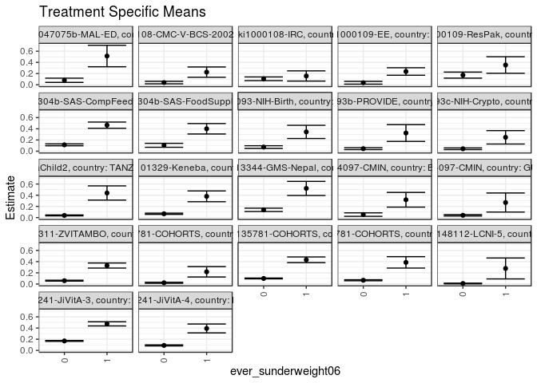

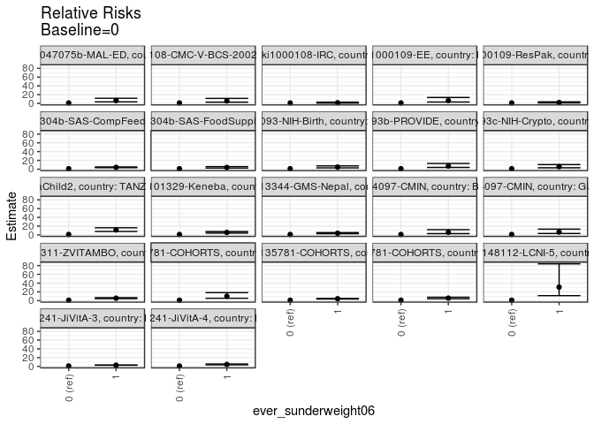

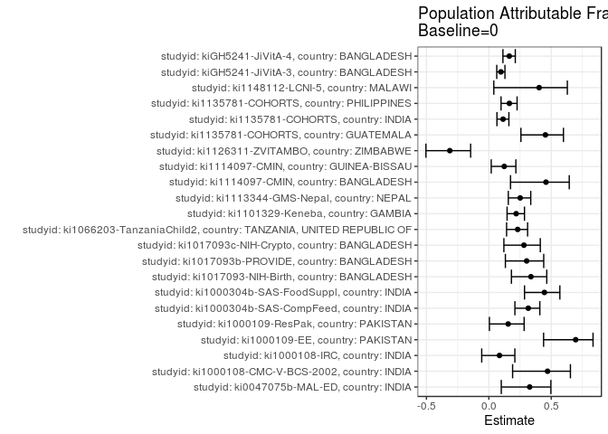

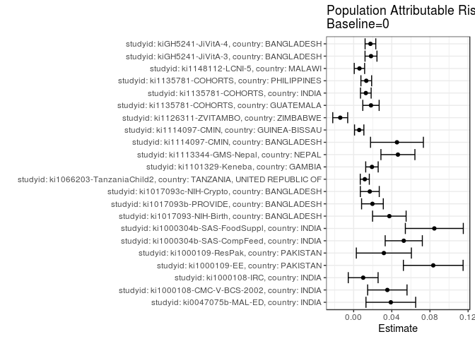

## Results Table

### Parameter: TSM

| studyid | country | intervention_level | baseline_level | estimate | ci_lower | ci_upper |
| --- | --- | --- | --- | --- | --- | --- |
| ki0047075b-MAL-ED | INDIA | 0 | NA | 0.0801676 | 0.0423693 | 0.1179659 |
| ki0047075b-MAL-ED | INDIA | 1 | NA | 0.5136889 | 0.3218250 | 0.7055528 |
| ki1000108-CMC-V-BCS-2002 | INDIA | 0 | NA | 0.0397477 | 0.0172729 | 0.0622226 |
| ki1000108-CMC-V-BCS-2002 | INDIA | 1 | NA | 0.2262170 | 0.1343317 | 0.3181022 |
| ki1000108-IRC | INDIA | 0 | NA | 0.1070828 | 0.0742941 | 0.1398715 |
| ki1000108-IRC | INDIA | 1 | NA | 0.1572597 | 0.0660232 | 0.2484963 |
| ki1000109-EE | PAKISTAN | 0 | NA | 0.0365297 | 0.0116498 | 0.0614095 |
| ki1000109-EE | PAKISTAN | 1 | NA | 0.2371795 | 0.1703427 | 0.3040162 |
| ki1000109-ResPak | PAKISTAN | 0 | NA | 0.1726633 | 0.1184754 | 0.2268512 |
| ki1000109-ResPak | PAKISTAN | 1 | NA | 0.3531440 | 0.2050867 | 0.5012013 |
| ki1000304b-SAS-CompFeed | INDIA | 0 | NA | 0.1137559 | 0.0971181 | 0.1303937 |
| ki1000304b-SAS-CompFeed | INDIA | 1 | NA | 0.4650547 | 0.4095840 | 0.5205254 |
| ki1000304b-SAS-FoodSuppl | INDIA | 0 | NA | 0.1053914 | 0.0698650 | 0.1409179 |
| ki1000304b-SAS-FoodSuppl | INDIA | 1 | NA | 0.4006663 | 0.3070559 | 0.4942767 |
| ki1017093-NIH-Birth | BANGLADESH | 0 | NA | 0.0734691 | 0.0494385 | 0.0974997 |
| ki1017093-NIH-Birth | BANGLADESH | 1 | NA | 0.3449336 | 0.2270049 | 0.4628624 |
| ki1017093b-PROVIDE | BANGLADESH | 0 | NA | 0.0453384 | 0.0282707 | 0.0624061 |
| ki1017093b-PROVIDE | BANGLADESH | 1 | NA | 0.3245583 | 0.1747034 | 0.4744133 |
| ki1017093c-NIH-Crypto | BANGLADESH | 0 | NA | 0.0433311 | 0.0280168 | 0.0586454 |
| ki1017093c-NIH-Crypto | BANGLADESH | 1 | NA | 0.2477514 | 0.1280034 | 0.3674993 |
| ki1066203-TanzaniaChild2 | TANZANIA, UNITED REPUBLIC OF | 0 | NA | 0.0388677 | 0.0303027 | 0.0474326 |
| ki1066203-TanzaniaChild2 | TANZANIA, UNITED REPUBLIC OF | 1 | NA | 0.4396151 | 0.3128181 | 0.5664120 |
| ki1101329-Keneba | GAMBIA | 0 | NA | 0.0684354 | 0.0573288 | 0.0795421 |
| ki1101329-Keneba | GAMBIA | 1 | NA | 0.3797078 | 0.2832029 | 0.4762127 |
| ki1113344-GMS-Nepal | NEPAL | 0 | NA | 0.1383170 | 0.1086127 | 0.1680212 |
| ki1113344-GMS-Nepal | NEPAL | 1 | NA | 0.5214605 | 0.3957864 | 0.6471347 |
| ki1114097-CMIN | BANGLADESH | 0 | NA | 0.0537864 | 0.0229052 | 0.0846675 |
| ki1114097-CMIN | BANGLADESH | 1 | NA | 0.3186091 | 0.1870983 | 0.4501199 |
| ki1114097-CMIN | GUINEA-BISSAU | 0 | NA | 0.0413306 | 0.0289377 | 0.0537236 |
| ki1114097-CMIN | GUINEA-BISSAU | 1 | NA | 0.2692308 | 0.0986511 | 0.4398105 |
| ki1126311-ZVITAMBO | ZIMBABWE | 0 | NA | 0.0590717 | 0.0506425 | 0.0675009 |
| ki1126311-ZVITAMBO | ZIMBABWE | 1 | NA | 0.3299922 | 0.2845594 | 0.3754250 |
| ki1135781-COHORTS | GUATEMALA | 0 | NA | 0.0219053 | 0.0124121 | 0.0313985 |
| ki1135781-COHORTS | GUATEMALA | 1 | NA | 0.2181772 | 0.1255269 | 0.3108275 |
| ki1135781-COHORTS | INDIA | 0 | NA | 0.0990276 | 0.0914881 | 0.1065671 |
| ki1135781-COHORTS | INDIA | 1 | NA | 0.4330344 | 0.3822868 | 0.4837821 |
| ki1135781-COHORTS | PHILIPPINES | 0 | NA | 0.0672147 | 0.0579234 | 0.0765059 |
| ki1135781-COHORTS | PHILIPPINES | 1 | NA | 0.3865591 | 0.2844271 | 0.4886911 |
| ki1148112-LCNI-5 | MALAWI | 0 | NA | 0.0089974 | 0.0023418 | 0.0156531 |
| ki1148112-LCNI-5 | MALAWI | 1 | NA | 0.2777778 | 0.0904991 | 0.4650565 |
| kiGH5241-JiVitA-3 | BANGLADESH | 0 | NA | 0.1697181 | 0.1617203 | 0.1777159 |
| kiGH5241-JiVitA-3 | BANGLADESH | 1 | NA | 0.4749991 | 0.4378846 | 0.5121137 |
| kiGH5241-JiVitA-4 | BANGLADESH | 0 | NA | 0.0897492 | 0.0798018 | 0.0996966 |
| kiGH5241-JiVitA-4 | BANGLADESH | 1 | NA | 0.3926471 | 0.3132820 | 0.4720121 |

### Parameter: E(Y)

| studyid | country | intervention_level | baseline_level | estimate | ci_lower | ci_upper |
| --- | --- | --- | --- | --- | --- | --- |
| ki0047075b-MAL-ED | INDIA | NA | NA | 0.1191489 | 0.0776405 | 0.1606574 |
| ki1000108-CMC-V-BCS-2002 | INDIA | NA | NA | 0.0750670 | 0.0482904 | 0.1018437 |
| ki1000108-IRC | INDIA | NA | NA | 0.1170732 | 0.0859146 | 0.1482317 |
| ki1000109-EE | PAKISTAN | NA | NA | 0.1200000 | 0.0870660 | 0.1529340 |
| ki1000109-ResPak | PAKISTAN | NA | NA | 0.2043478 | 0.1521230 | 0.2565727 |
| ki1000304b-SAS-CompFeed | INDIA | NA | NA | 0.1663067 | 0.1478935 | 0.1847199 |
| ki1000304b-SAS-FoodSuppl | INDIA | NA | NA | 0.1900000 | 0.1515071 | 0.2284929 |
| ki1017093-NIH-Birth | BANGLADESH | NA | NA | 0.1109057 | 0.0844206 | 0.1373909 |
| ki1017093b-PROVIDE | BANGLADESH | NA | NA | 0.0650407 | 0.0455353 | 0.0845460 |
| ki1017093c-NIH-Crypto | BANGLADESH | NA | NA | 0.0602740 | 0.0429977 | 0.0775502 |
| ki1066203-TanzaniaChild2 | TANZANIA, UNITED REPUBLIC OF | NA | NA | 0.0505451 | 0.0409848 | 0.0601054 |
| ki1101329-Keneba | GAMBIA | NA | NA | 0.0876266 | 0.0759950 | 0.0992582 |
| ki1113344-GMS-Nepal | NEPAL | NA | NA | 0.1847458 | 0.1534039 | 0.2160876 |
| ki1114097-CMIN | BANGLADESH | NA | NA | 0.0992063 | 0.0622241 | 0.1361886 |
| ki1114097-CMIN | GUINEA-BISSAU | NA | NA | 0.0471513 | 0.0341242 | 0.0601783 |
| ki1126311-ZVITAMBO | ZIMBABWE | NA | NA | 0.0449980 | 0.0410967 | 0.0488994 |
| ki1135781-COHORTS | GUATEMALA | NA | NA | 0.0400782 | 0.0280529 | 0.0521035 |
| ki1135781-COHORTS | INDIA | NA | NA | 0.1117877 | 0.1043506 | 0.1192249 |
| ki1135781-COHORTS | PHILIPPINES | NA | NA | 0.0804557 | 0.0703953 | 0.0905161 |
| ki1148112-LCNI-5 | MALAWI | NA | NA | 0.0150754 | 0.0066051 | 0.0235457 |
| kiGH5241-JiVitA-3 | BANGLADESH | NA | NA | 0.1879125 | 0.1813641 | 0.1944608 |
| kiGH5241-JiVitA-4 | BANGLADESH | NA | NA | 0.1073532 | 0.0971813 | 0.1175251 |

### Parameter: RR

| studyid | country | intervention_level | baseline_level | estimate | ci_lower | ci_upper |
| --- | --- | --- | --- | --- | --- | --- |
| ki0047075b-MAL-ED | INDIA | 0 | 0 | 1.000000 | 1.0000000 | 1.000000 |
| ki0047075b-MAL-ED | INDIA | 1 | 0 | 6.407687 | 3.5108329 | 11.694789 |
| ki1000108-CMC-V-BCS-2002 | INDIA | 0 | 0 | 1.000000 | 1.0000000 | 1.000000 |
| ki1000108-CMC-V-BCS-2002 | INDIA | 1 | 0 | 5.691320 | 2.8230838 | 11.473669 |
| ki1000108-IRC | INDIA | 0 | 0 | 1.000000 | 1.0000000 | 1.000000 |
| ki1000108-IRC | INDIA | 1 | 0 | 1.468580 | 0.7619481 | 2.830544 |
| ki1000109-EE | PAKISTAN | 0 | 0 | 1.000000 | 1.0000000 | 1.000000 |
| ki1000109-EE | PAKISTAN | 1 | 0 | 6.492788 | 3.1068548 | 13.568803 |
| ki1000109-ResPak | PAKISTAN | 0 | 0 | 1.000000 | 1.0000000 | 1.000000 |
| ki1000109-ResPak | PAKISTAN | 1 | 0 | 2.045275 | 1.2114574 | 3.452991 |
| ki1000304b-SAS-CompFeed | INDIA | 0 | 0 | 1.000000 | 1.0000000 | 1.000000 |
| ki1000304b-SAS-CompFeed | INDIA | 1 | 0 | 4.088182 | 3.3331653 | 5.014222 |
| ki1000304b-SAS-FoodSuppl | INDIA | 0 | 0 | 1.000000 | 1.0000000 | 1.000000 |
| ki1000304b-SAS-FoodSuppl | INDIA | 1 | 0 | 3.801696 | 2.5175507 | 5.740856 |
| ki1017093-NIH-Birth | BANGLADESH | 0 | 0 | 1.000000 | 1.0000000 | 1.000000 |
| ki1017093-NIH-Birth | BANGLADESH | 1 | 0 | 4.694949 | 2.9227785 | 7.541642 |
| ki1017093b-PROVIDE | BANGLADESH | 0 | 0 | 1.000000 | 1.0000000 | 1.000000 |
| ki1017093b-PROVIDE | BANGLADESH | 1 | 0 | 7.158574 | 3.9427529 | 12.997310 |
| ki1017093c-NIH-Crypto | BANGLADESH | 0 | 0 | 1.000000 | 1.0000000 | 1.000000 |
| ki1017093c-NIH-Crypto | BANGLADESH | 1 | 0 | 5.717633 | 3.1423891 | 10.403334 |
| ki1066203-TanzaniaChild2 | TANZANIA, UNITED REPUBLIC OF | 0 | 0 | 1.000000 | 1.0000000 | 1.000000 |
| ki1066203-TanzaniaChild2 | TANZANIA, UNITED REPUBLIC OF | 1 | 0 | 11.310551 | 7.8651333 | 16.265277 |
| ki1101329-Keneba | GAMBIA | 0 | 0 | 1.000000 | 1.0000000 | 1.000000 |
| ki1101329-Keneba | GAMBIA | 1 | 0 | 5.548410 | 4.1047129 | 7.499879 |
| ki1113344-GMS-Nepal | NEPAL | 0 | 0 | 1.000000 | 1.0000000 | 1.000000 |
| ki1113344-GMS-Nepal | NEPAL | 1 | 0 | 3.770040 | 2.7283858 | 5.209380 |
| ki1114097-CMIN | BANGLADESH | 0 | 0 | 1.000000 | 1.0000000 | 1.000000 |
| ki1114097-CMIN | BANGLADESH | 1 | 0 | 5.923602 | 2.9164123 | 12.031585 |
| ki1114097-CMIN | GUINEA-BISSAU | 0 | 0 | 1.000000 | 1.0000000 | 1.000000 |
| ki1114097-CMIN | GUINEA-BISSAU | 1 | 0 | 6.514071 | 3.2317093 | 13.130242 |
| ki1126311-ZVITAMBO | ZIMBABWE | 0 | 0 | 1.000000 | 1.0000000 | 1.000000 |
| ki1126311-ZVITAMBO | ZIMBABWE | 1 | 0 | 5.586298 | 4.5795735 | 6.814329 |
| ki1135781-COHORTS | GUATEMALA | 0 | 0 | 1.000000 | 1.0000000 | 1.000000 |
| ki1135781-COHORTS | GUATEMALA | 1 | 0 | 9.960008 | 5.4338325 | 18.256317 |
| ki1135781-COHORTS | INDIA | 0 | 0 | 1.000000 | 1.0000000 | 1.000000 |
| ki1135781-COHORTS | INDIA | 1 | 0 | 4.372865 | 3.8026465 | 5.028590 |
| ki1135781-COHORTS | PHILIPPINES | 0 | 0 | 1.000000 | 1.0000000 | 1.000000 |
| ki1135781-COHORTS | PHILIPPINES | 1 | 0 | 5.751113 | 4.2689735 | 7.747835 |
| ki1148112-LCNI-5 | MALAWI | 0 | 0 | 1.000000 | 1.0000000 | 1.000000 |
| ki1148112-LCNI-5 | MALAWI | 1 | 0 | 30.873016 | 11.3476420 | 83.994817 |
| kiGH5241-JiVitA-3 | BANGLADESH | 0 | 0 | 1.000000 | 1.0000000 | 1.000000 |
| kiGH5241-JiVitA-3 | BANGLADESH | 1 | 0 | 2.798753 | 2.5511537 | 3.070383 |
| kiGH5241-JiVitA-4 | BANGLADESH | 0 | 0 | 1.000000 | 1.0000000 | 1.000000 |
| kiGH5241-JiVitA-4 | BANGLADESH | 1 | 0 | 4.374935 | 3.4740323 | 5.509464 |

### Parameter: PAR

| studyid | country | intervention_level | baseline_level | estimate | ci_lower | ci_upper |
| --- | --- | --- | --- | --- | --- | --- |
| ki0047075b-MAL-ED | INDIA | 0 | NA | 0.0389813 | 0.0129204 | 0.0650423 |
| ki1000108-CMC-V-BCS-2002 | INDIA | 0 | NA | 0.0353193 | 0.0146710 | 0.0559676 |
| ki1000108-IRC | INDIA | 0 | NA | 0.0099903 | -0.0056542 | 0.0256349 |
| ki1000109-EE | PAKISTAN | 0 | NA | 0.0834703 | 0.0521549 | 0.1147857 |
| ki1000109-ResPak | PAKISTAN | 0 | NA | 0.0316845 | 0.0028247 | 0.0605443 |
| ki1000304b-SAS-CompFeed | INDIA | 0 | NA | 0.0525508 | 0.0330698 | 0.0720318 |
| ki1000304b-SAS-FoodSuppl | INDIA | 0 | NA | 0.0846086 | 0.0542169 | 0.1150002 |
| ki1017093-NIH-Birth | BANGLADESH | 0 | NA | 0.0374366 | 0.0198459 | 0.0550274 |
| ki1017093b-PROVIDE | BANGLADESH | 0 | NA | 0.0197022 | 0.0083201 | 0.0310844 |
| ki1017093c-NIH-Crypto | BANGLADESH | 0 | NA | 0.0169429 | 0.0070287 | 0.0268570 |
| ki1066203-TanzaniaChild2 | TANZANIA, UNITED REPUBLIC OF | 0 | NA | 0.0116774 | 0.0069297 | 0.0164251 |
| ki1101329-Keneba | GAMBIA | 0 | NA | 0.0191912 | 0.0126568 | 0.0257256 |
| ki1113344-GMS-Nepal | NEPAL | 0 | NA | 0.0464288 | 0.0286144 | 0.0642431 |
| ki1114097-CMIN | BANGLADESH | 0 | NA | 0.0454200 | 0.0177007 | 0.0731393 |
| ki1114097-CMIN | GUINEA-BISSAU | 0 | NA | 0.0058206 | 0.0009254 | 0.0107159 |
| ki1126311-ZVITAMBO | ZIMBABWE | 0 | NA | -0.0140737 | -0.0219047 | -0.0062427 |
| ki1135781-COHORTS | GUATEMALA | 0 | NA | 0.0181729 | 0.0096008 | 0.0267449 |
| ki1135781-COHORTS | INDIA | 0 | NA | 0.0127601 | 0.0071687 | 0.0183515 |
| ki1135781-COHORTS | PHILIPPINES | 0 | NA | 0.0132410 | 0.0076209 | 0.0188611 |
| ki1148112-LCNI-5 | MALAWI | 0 | NA | 0.0060779 | 0.0006315 | 0.0115244 |
| kiGH5241-JiVitA-3 | BANGLADESH | 0 | NA | 0.0181943 | 0.0119302 | 0.0244585 |
| kiGH5241-JiVitA-4 | BANGLADESH | 0 | NA | 0.0176040 | 0.0119984 | 0.0232095 |

### Parameter: PAF

| studyid | country | intervention_level | baseline_level | estimate | ci_lower | ci_upper |
| --- | --- | --- | --- | --- | --- | --- |
| ki0047075b-MAL-ED | INDIA | 0 | NA | 0.3271647 | 0.0996896 | 0.4971653 |
| ki1000108-CMC-V-BCS-2002 | INDIA | 0 | NA | 0.4705037 | 0.1904353 | 0.6536826 |
| ki1000108-IRC | INDIA | 0 | NA | 0.0853342 | -0.0569901 | 0.2084944 |
| ki1000109-EE | PAKISTAN | 0 | NA | 0.6955860 | 0.4387525 | 0.8348894 |
| ki1000109-ResPak | PAKISTAN | 0 | NA | 0.1550519 | 0.0044837 | 0.2828472 |
| ki1000304b-SAS-CompFeed | INDIA | 0 | NA | 0.3159874 | 0.2088952 | 0.4085825 |
| ki1000304b-SAS-FoodSuppl | INDIA | 0 | NA | 0.4453082 | 0.2859507 | 0.5691011 |
| ki1017093-NIH-Birth | BANGLADESH | 0 | NA | 0.3375537 | 0.1809536 | 0.4642123 |
| ki1017093b-PROVIDE | BANGLADESH | 0 | NA | 0.3029220 | 0.1326148 | 0.4397902 |
| ki1017093c-NIH-Crypto | BANGLADESH | 0 | NA | 0.2810975 | 0.1205699 | 0.4123231 |
| ki1066203-TanzaniaChild2 | TANZANIA, UNITED REPUBLIC OF | 0 | NA | 0.2310293 | 0.1422261 | 0.3106389 |
| ki1101329-Keneba | GAMBIA | 0 | NA | 0.2190107 | 0.1461880 | 0.2856222 |
| ki1113344-GMS-Nepal | NEPAL | 0 | NA | 0.2513117 | 0.1560366 | 0.3358312 |
| ki1114097-CMIN | BANGLADESH | 0 | NA | 0.4578334 | 0.1736969 | 0.6442654 |
| ki1114097-CMIN | GUINEA-BISSAU | 0 | NA | 0.1234459 | 0.0191191 | 0.2166765 |
| ki1126311-ZVITAMBO | ZIMBABWE | 0 | NA | -0.3127618 | -0.5039921 | -0.1458462 |
| ki1135781-COHORTS | GUATEMALA | 0 | NA | 0.4534355 | 0.2571271 | 0.5978682 |
| ki1135781-COHORTS | INDIA | 0 | NA | 0.1141459 | 0.0649991 | 0.1607095 |
| ki1135781-COHORTS | PHILIPPINES | 0 | NA | 0.1645754 | 0.0978452 | 0.2263697 |
| ki1148112-LCNI-5 | MALAWI | 0 | NA | 0.4031705 | 0.0398585 | 0.6290074 |
| kiGH5241-JiVitA-3 | BANGLADESH | 0 | NA | 0.0968235 | 0.0634677 | 0.1289913 |
| kiGH5241-JiVitA-4 | BANGLADESH | 0 | NA | 0.1639819 | 0.1129196 | 0.2121049 |